# Does Home-Court Advantage Disappear Without Fans? Evidence from the NBA, 2015–2025

Nan Xiao

2026-11-07

# 1 Introduction

Home-court advantage is one of the most consistent patterns in sports: NBA home teams historically win roughly 58–60% of games. But *why* home teams win is debated. Possible explanations include crowd support, referee bias influenced by crowds, travel fatigue for the visiting team, and familiarity with the arena.

The COVID-19 pandemic created a **natural experiment**. From July to October 2020 the NBA finished its season in a “bubble” at a neutral site with no fans, and for much of the 2020–21 season teams played in their own arenas with no or limited fans. This lets us separate the effect of **crowds** from the effect of **travel and familiarity**.

**Research questions**

1. Was the home team’s winning percentage lower in games played without fans?
2. Does this difference remain after controlling for the relative strength of the two teams?
3. Does playing in the home arena *without* fans still give an advantage, compared with the neutral-site bubble?

This question matters beyond basketball trivia. If fans are the main source of home-court advantage, then crowds have a measurable effect on game outcomes, which is relevant for sports betting models, ticket pricing, and how leagues think about scheduling and referee training.

# 2 Data

```r
games <- read_csv("data/nba_games_2015_2025.csv")
```

The data come from ESPN via the `hoopR` R package and cover all completed regular-season and playoff games from the 2014–15 season through the 2024–25 season (**14,126 games**). Each row is one game, with the home and away teams, final scores, and reported attendance.

## 2.1 Defining the crowd condition

```r
games <- games |>
  mutate(
    home_win = as.integer(home_score > away_score),
    margin   = home_score - away_score,           # home point margin
    bubble   = venue == "ESPN Wide World of Sports Complex",
    crowd = case_when(
      bubble                                   ~ "Bubble (neutral, no fans)",
      season == 2021 & attendance == 0         ~ "Home arena, no fans",
      season == 2021 & attendance < 10000      ~ "Limited fans",
      TRUE                                     ~ "Full crowd"
    ),
    crowd = factor(crowd, levels = c("Full crowd", "Limited fans",
                                     "Home arena, no fans", "Bubble (neutral, no fans)")),
    playoffs = season_type == "Playoffs"
  )

games |> count(crowd) |> knitr::kable(col.names = c("Crowd condition", "Games"))
```

| Crowd condition | Games |
| --- | --- |
| Full crowd | 12857 |
| Limited fans | 522 |
| Home arena, no fans | 576 |
| Bubble (neutral, no fans) | 171 |

- **Bubble**: all games at the Orlando bubble (July–October 2020). Neither team is really “at home”.
- **Home arena, no fans**: 2020–21 season games with reported attendance of zero.
- **Limited fans**: 2020–21 games with between 1 and 9,999 fans.
- **Full crowd**: all other games.

A small number of zero-attendance games outside 2020–21 are likely data-entry errors and are treated as full-crowd games.

## 2.2 Controlling for team strength

Better teams win more often regardless of location, so we need a measure of team quality. For each team-season we compute the team’s overall regular-season winning percentage, and define `strength_diff` = home team win% − away team win%.

```r
team_season <- games |>
  filter(season_type == "Regular") |>
  select(season, home_team, away_team, home_win) |>
  pivot_longer(c(home_team, away_team), names_to = "side", values_to = "team") |>
  mutate(win = if_else(side == "home_team", home_win, 1L - home_win)) |>
  group_by(season, team) |>
  summarise(win_pct = mean(win), .groups = "drop")

games <- games |>
  left_join(team_season, by = c("season", "home_team" = "team")) |>
  rename(home_wpct = win_pct) |>
  left_join(team_season, by = c("season", "away_team" = "team")) |>
  rename(away_wpct = win_pct) |>
  mutate(strength_diff = home_wpct - away_wpct)
```

# 3 Exploratory Data Analysis

## 3.1 Home win percentage by season

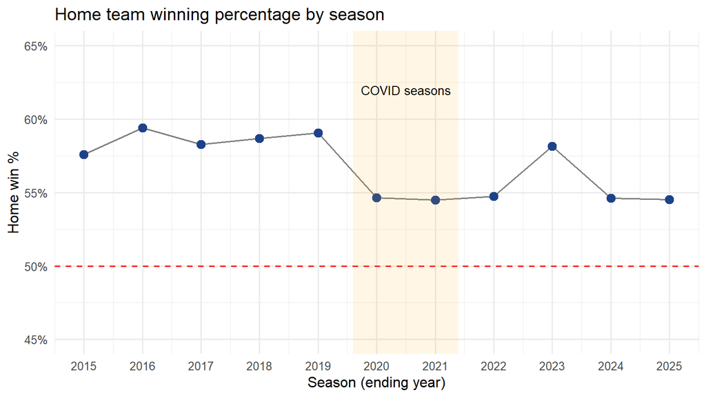

```r
games |>
  group_by(season) |>
  summarise(home_win_pct = mean(home_win), n = n()) |>
  ggplot(aes(season, home_win_pct)) +
  geom_line(color = "grey50") +
  geom_point(size = 3, color = "#1d428a") +
  geom_hline(yintercept = 0.5, linetype = "dashed", color = "red") +
  annotate("rect", xmin = 2019.6, xmax = 2021.4, ymin = -Inf, ymax = Inf,
           alpha = 0.1, fill = "orange") +
  annotate("text", x = 2020.5, y = 0.62, label = "COVID seasons", size = 3.5) +
  scale_x_continuous(breaks = 2015:2025) +
  scale_y_continuous(labels = scales::percent, limits = c(0.45, 0.65)) +
  labs(x = "Season (ending year)", y = "Home win %",
       title = "Home team winning percentage by season")
```

```r
era <- games |>
  mutate(era = case_when(season <= 2019 ~ "Pre-COVID (2015–2019)",
                         season >= 2022 ~ "Post-COVID (2022–2025)",
                         TRUE           ~ "COVID (2020–2021)")) |>
  group_by(era) |>
  summarise(home_win_pct = mean(home_win), games = n())
pre_pct  <- era$home_win_pct[era$era == "Pre-COVID (2015–2019)"]
post_pct <- era$home_win_pct[era$era == "Post-COVID (2022–2025)"]
```

Before COVID, home teams won about 58.6% of games. The rate dropped during the 2020 and 2021 seasons, but it did **not** fully bounce back once fans returned: from 2022 to 2025 home teams won only 55.5% of games. This suggests home-court advantage was already shrinking for reasons unrelated to COVID (for example, better travel and sleep management, or more three-point shooting, which adds randomness). We keep this trend in mind when interpreting the no-fan effect.

## 3.2 Home win percentage and point margin by crowd condition

```r
crowd_summary <- games |>
  group_by(crowd) |>
  summarise(
    games        = n(),
    home_win_pct = mean(home_win),
    se           = sqrt(home_win_pct * (1 - home_win_pct) / games),
    avg_margin   = mean(margin)
  )

crowd_summary |>
  mutate(home_win_pct = scales::percent(home_win_pct, 0.1),
         se = round(se, 3), avg_margin = round(avg_margin, 2)) |>
  knitr::kable(col.names = c("Crowd", "Games", "Home win %", "SE", "Avg home margin"))
```

| Crowd | Games | Home win % | SE | Avg home margin |
| --- | --- | --- | --- | --- |
| Full crowd | 12857 | 57.1% | 0.004 | 2.46 |
| Limited fans | 522 | 58.6% | 0.022 | 2.24 |
| Home arena, no fans | 576 | 50.3% | 0.021 | -0.15 |
| Bubble (neutral, no fans) | 171 | 52.0% | 0.038 | 1.33 |

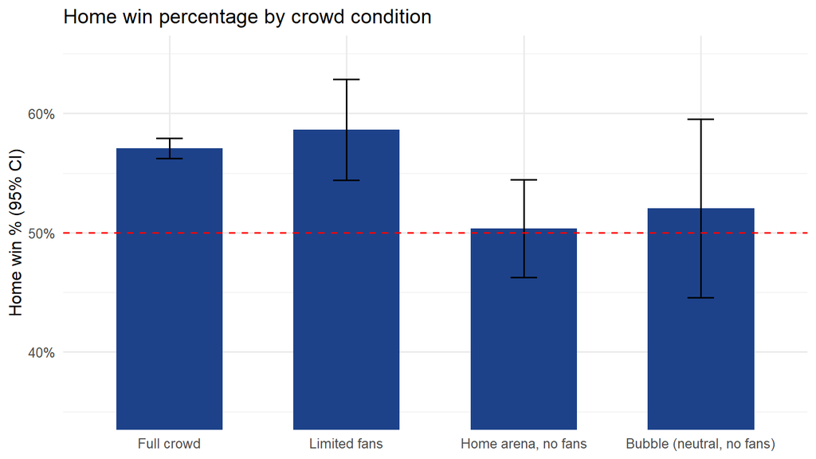

```r
ggplot(crowd_summary, aes(crowd, home_win_pct)) +
  geom_col(fill = "#1d428a", width = 0.6) +
  geom_errorbar(aes(ymin = home_win_pct - 1.96 * se, ymax = home_win_pct + 1.96 * se),
                width = 0.15) +
  geom_hline(yintercept = 0.5, linetype = "dashed", color = "red") +
  scale_y_continuous(labels = scales::percent) +
  coord_cartesian(ylim = c(0.35, 0.65)) +
  labs(x = NULL, y = "Home win % (95% CI)",
       title = "Home win percentage by crowd condition")
```

## 3.3 Distribution of home point margin

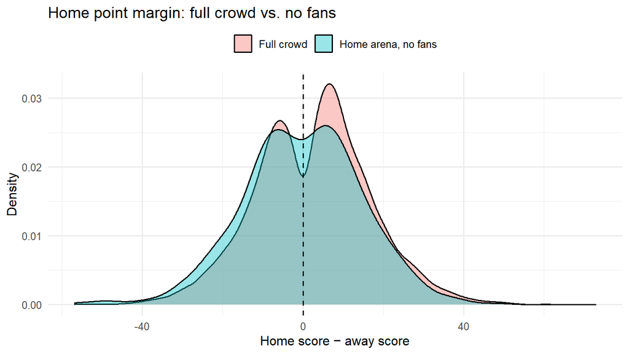

```r
games |>
  filter(crowd %in% c("Full crowd", "Home arena, no fans")) |>
  ggplot(aes(margin, fill = crowd)) +
  geom_density(alpha = 0.4) +
  geom_vline(xintercept = 0, linetype = "dashed") +
  labs(x = "Home score − away score", y = "Density", fill = NULL,
       title = "Home point margin: full crowd vs. no fans") +
  theme(legend.position = "top")
```

Both distributions are roughly bell-shaped and have similar spreads (SD of about 14.4 points with a full crowd and 14.8 without fans). The no-fan curve is shifted slightly to the left, meaning home teams won by fewer points. The shift is small compared with the overall spread, so any single game is still very unpredictable. Since the samples are large and the shapes are close to normal, a t-test is appropriate here.

# 4 Methods

1. **Two-proportion z-test**: compare the home win rate in full-crowd games vs. no-fan games.
2. **Welch two-sample t-test**: compare the average home point margin.
3. **Logistic regression**: model the probability of a home win as a function of crowd condition, controlling for team strength difference and playoff games.
4. **Linear regression**: model the home point margin with the same predictors, as a robustness check.

# 5 Results

## 5.1 Hypothesis tests

**H₀:** the home win probability is the same with and without fans. **H₁:** the home win probability is different.

```r
full   <- games |> filter(crowd == "Full crowd")
nofans <- games |> filter(crowd == "Home arena, no fans")
bubble <- games |> filter(crowd == "Bubble (neutral, no fans)")

pt <- prop.test(x = c(sum(full$home_win), sum(nofans$home_win)),
                n = c(nrow(full), nrow(nofans)))
pt
```

```
##
##  2-sample test for equality of proportions with continuity correction
##
## data:  c(sum(full$home_win), sum(nofans$home_win)) out of c(nrow(full), nrow(nofans))
## X-squared = 9.8933, df = 1, p-value = 0.001659
## alternative hypothesis: two.sided
## 95 percent confidence interval:
##  0.02464216 0.10989274
## sample estimates:
##    prop 1    prop 2
## 0.5707397 0.5034722
```

```r
tt <- t.test(full$margin, nofans$margin)   # Welch t-test by default (does not assume equal variances)
tt
```

```
##
##  Welch Two Sample t-test
##
## data:  full$margin and nofans$margin
## t = 4.1519, df = 625.26, p-value = 3.755e-05
## alternative hypothesis: true difference in means is not equal to 0
## 95 percent confidence interval:
##  1.374469 3.841513
## sample estimates:
##  mean of x  mean of y
##  2.4569495 -0.1510417
```

```r
# Bubble: is the home win rate significantly different from 50%?
binom.test(sum(bubble$home_win), nrow(bubble), p = 0.5)
```

```
##
##  Exact binomial test
##
## data:  sum(bubble$home_win) and nrow(bubble)
## number of successes = 89, number of trials = 171, p-value = 0.6465
## alternative hypothesis: true probability of success is not equal to 0.5
## 95 percent confidence interval:
##  0.4428809 0.5973331
## sample estimates:
## probability of success
##              0.5204678
```

The home win rate was 57.1% with a full crowd and 50.3% in home arenas without fans (p = 0.00166). The average home margin fell from 2.46 to -0.15 points (p = 3.75^{-5}).

Both p-values are well below 0.05, so we **reject H₀**: home teams did significantly worse without fans. The difference is also meaningful in practice. A drop of about 6.7 percentage points means that, without fans, the home team was barely more likely to win than a coin flip. In the bubble, the home win rate was also not significantly different from 50%, which makes sense because the “home” team was just a label there.

## 5.2 Logistic regression

$$\log\frac{P(\text{home
win})}{1-P(\text{home win})} = \beta_0 + \beta_1\,\text{crowd} +
\beta_2\,\text{strength\_diff} + \beta_3\,\text{playoffs}$$

```r
logit <- glm(home_win ~ crowd + strength_diff + playoffs,
             data = games, family = binomial)
summary(logit)
```

```
##
## Call:
## glm(formula = home_win ~ crowd + strength_diff + playoffs, family = binomial,
##     data = games)
##
## Coefficients:
##                                Estimate Std. Error z value Pr(>|z|)
## (Intercept)                     0.33832    0.02037  16.610  < 2e-16 ***
## crowdLimited fans               0.09561    0.09966   0.959 0.337415
## crowdHome arena, no fans       -0.33103    0.09232  -3.586 0.000336 ***
## crowdBubble (neutral, no fans) -0.29967    0.16522  -1.814 0.069722 .
## strength_diff                   4.68801    0.10494  44.672  < 2e-16 ***
## playoffsTRUE                    0.04167    0.07419   0.562 0.574288
## ---
## Signif. codes:  0 '***' 0.001 '**' 0.01 '*' 0.05 '.' 0.1 ' ' 1
##
## (Dispersion parameter for binomial family taken to be 1)
##
##     Null deviance: 19321  on 14125  degrees of freedom
## Residual deviance: 16755  on 14120  degrees of freedom
## AIC: 16767
##
## Number of Fisher Scoring iterations: 3
```

Odds ratios with 95% confidence intervals:

```r
tidy(logit, exponentiate = TRUE, conf.int = TRUE) |>
  mutate(across(where(is.numeric), \(x) round(x, 3))) |>
  knitr::kable()
```

| term | estimate | std.error | statistic | p.value | conf.low | conf.high |
| --- | --- | --- | --- | --- | --- | --- |
| (Intercept) | 1.403 | 0.020 | 16.610 | 0.000 | 1.348 | 1.460 |
| crowdLimited fans | 1.100 | 0.100 | 0.959 | 0.337 | 0.906 | 1.339 |
| crowdHome arena, no fans | 0.718 | 0.092 | -3.586 | 0.000 | 0.599 | 0.861 |
| crowdBubble (neutral, no fans) | 0.741 | 0.165 | -1.814 | 0.070 | 0.536 | 1.025 |
| strength_diff | 108.637 | 0.105 | 44.672 | 0.000 | 88.549 | 133.613 |
| playoffsTRUE | 1.043 | 0.074 | 0.562 | 0.574 | 0.902 | 1.206 |

```r
# Convert to probabilities: predicted home win % for two evenly matched teams
# (strength_diff = 0) in a regular-season game
newdata <- tibble(crowd = factor(levels(games$crowd), levels = levels(games$crowd)),
                  strength_diff = 0, playoffs = FALSE)
newdata |>
  mutate(pred_home_win = predict(logit, newdata, type = "response")) |>
  mutate(pred_home_win = scales::percent(pred_home_win, 0.1)) |>
  select(crowd, pred_home_win) |>
  knitr::kable(col.names = c("Crowd", "Predicted home win % (evenly matched teams)"))
```

| Crowd | Predicted home win % (evenly matched teams) |
| --- | --- |
| Full crowd | 58.4% |
| Limited fans | 60.7% |
| Home arena, no fans | 50.2% |
| Bubble (neutral, no fans) | 51.0% |

Holding team strength and game type constant, the odds of a home win in a home arena without fans were about **0.72 times** the odds with a full crowd (95% CI: 0.6 to 0.86). Since the whole interval is below 1, the drop is statistically significant. The bubble estimate is similar (OR = 0.74), but its interval includes 1 because there were only 171 bubble games. Games with limited fans did not differ significantly from full-crowd games, which suggests even a small crowd may be enough to restore some advantage.

Team strength is by far the strongest predictor. A 0.1 increase in `strength_diff` (for example, a .600 team hosting a .500 team) multiplies the odds of a home win by about 1.6. Playoff games were not significantly different from regular-season games.

The prediction table makes this easier to read: for two evenly matched teams, the model predicts the home team wins about 58% of the time with a full crowd, but only about 50% in a home arena without fans, which is essentially no advantage at all.

## 5.3 Linear regression on point margin

```r
lm_margin <- lm(margin ~ crowd + strength_diff + playoffs, data = games)
summary(lm_margin)
```

```
##
## Call:
## lm(formula = margin ~ crowd + strength_diff + playoffs, data = games)
##
## Residuals:
##     Min      1Q  Median      3Q     Max
## -54.578  -8.182  -0.180   8.064  58.722
##
## Coefficients:
##                                Estimate Std. Error t value Pr(>|t|)
## (Intercept)                     2.33995    0.11806  19.819  < 2e-16 ***
## crowdLimited fans              -0.05719    0.58002  -0.099 0.921464
## crowdHome arena, no fans       -2.56292    0.55376  -4.628 3.72e-06 ***
## crowdBubble (neutral, no fans) -1.97831    1.01779  -1.944 0.051948 .
## strength_diff                  30.59239    0.52342  58.448  < 2e-16 ***
## playoffsTRUE                    1.59601    0.45280   3.525 0.000425 ***
## ---
## Signif. codes:  0 '***' 0.001 '**' 0.01 '*' 0.05 '.' 0.1 ' ' 1
##
## Residual standard error: 12.99 on 14120 degrees of freedom
## Multiple R-squared:  0.1967, Adjusted R-squared:  0.1964
## F-statistic: 691.4 on 5 and 14120 DF,  p-value: < 2.2e-16
```

The intercept (2.34) means that when two evenly matched teams play a regular-season game in front of a full crowd, the home team wins by about 2.3 points on average. Without fans in the home arena, this margin drops by about 2.6 points (p < 0.001), which wipes out the home advantage almost completely. The bubble coefficient (-2) points the same way but is only borderline significant (p ≈ 0.05). These results agree with the logistic model. Interestingly, playoff games show a slightly larger home margin (about 1.6 extra points), even though the playoff effect on win probability was not significant.

The model’s R² is only 0.2, so most of the variation in point margin is unexplained. This is expected: individual games depend on injuries, hot shooting, and luck. Our goal is to estimate the crowd effect, not to predict single games.

## 5.4 Model diagnostics

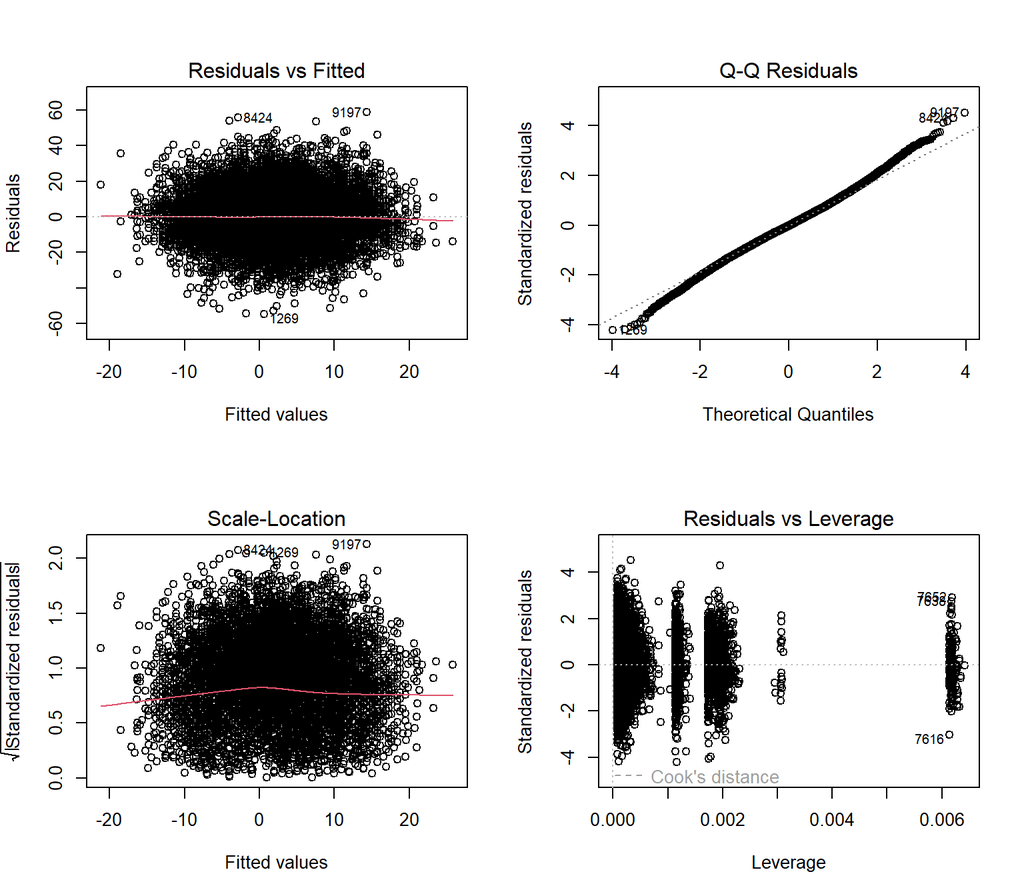

```r
par(mfrow = c(2, 2))
plot(lm_margin)
```

```r
par(mfrow = c(1, 1))
```

```r
vif(lm_margin)   # GVIF^(1/(2*Df)) below ~2 means no serious multicollinearity
```

```
##                   GVIF Df GVIF^(1/(2*Df))
## crowd         1.040191  3        1.006589
## strength_diff 1.000153  1        1.000077
## playoffs      1.040310  1        1.019956
```

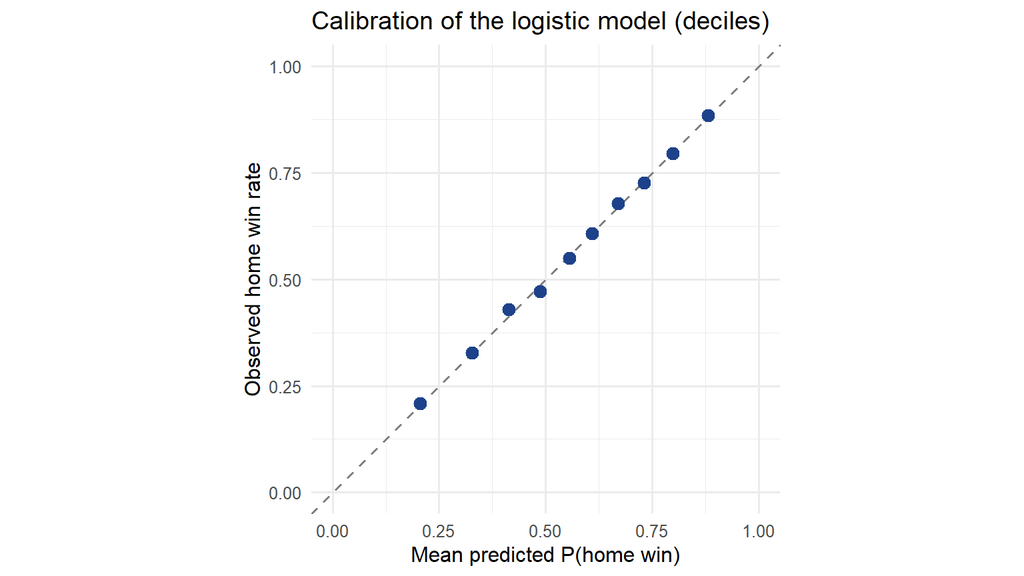

```r
# Calibration check: split predicted probabilities into 10 groups and
# compare predicted vs. observed home win rates
games |>
  mutate(pred = predict(logit, type = "response"),
         bin  = ntile(pred, 10)) |>
  group_by(bin) |>
  summarise(predicted = mean(pred), observed = mean(home_win)) |>
  ggplot(aes(predicted, observed)) +
  geom_abline(linetype = "dashed", color = "grey50") +
  geom_point(size = 3, color = "#1d428a") +
  coord_equal(xlim = c(0, 1), ylim = c(0, 1)) +
  labs(x = "Mean predicted P(home win)", y = "Observed home win rate",
       title = "Calibration of the logistic model (deciles)")
```

The residuals vs. fitted plot shows no clear pattern, so the linear form looks reasonable and the variance is roughly constant. The Q-Q plot follows the line closely, with only slightly heavier tails (a few blowout games), which is not a concern with over 14,000 observations. No single game has high leverage. All VIF values are close to 1, so there is no multicollinearity. For the logistic model, the calibration points lie almost exactly on the diagonal, meaning the predicted probabilities match the observed win rates well.

One assumption that is not perfectly met is **independence**: games involving the same team in the same season are related. This could make our standard errors a little too small, but it is unlikely to change the main conclusion given how small the p-values are.